# Detection of outlier SNPs based on temporal differentiation using SLiM simulations

```r
library(tidyverse)
library(qvalue)
library(reshape)
library(ggpubr)
library(vcfR)
library(microbenchmark)
library(matrixStats)
```

### 1. Loading datasets

```r
files <- c("High_Ne_HLG_FST_real_5000simulations.txt",
           "High_Ne_ROS_FST_real_5000simulations.txt",
           "High_Ne_QUI_FST_real_5000simulations.txt")
FST <- lapply(files, function(x) read.table(x, header = T, stringsAsFactors = F))

obj.vcfR <- vcfR::read.vcfR("VCF_2067_SNPs_at_T1_3pops.vcf", verbose = FALSE)

df_TempDiff <- read.table("Temporal_outliers_TempoDiff_qval0.10.txt", header = T,
stringsAsFactors = F)
df_OutFLANK <- read.table("Temporal_outliers_outflank_qval0.10.txt", header = T, stringsAsFactors = F)
```

### 2. Calculting P-value for each of the three populations

Proportion of simulations with F<sub>ST</sub> values equal or larger to the  
observed F<sub>ST</sub> after being corrected for multiple testing

```r
POP <- c("HLG","ROS","QUI")
n = 5000
alpha = 0.10

df_POP_FST_count <- list()
N_observations <-list()
qval <- list()
outliers_HighFST <- list()
header <- c("CHROM","POS","real_FST",paste(rep("simu",n),seq(1,n,1),sep = ""))

for (i in 1: length(POP)){

  POP_FST <- as.data.frame(FST[[i]])
  colnames(POP_FST) <- header

  POP_FST_count <- POP_FST %>%
  group_by(CHROM,POS) %>%
  dplyr::count(POP_FST[,4:(n+3)] >= real_FST)
  df_POP_FST_count[[i]] <- data.frame(as.matrix(POP_FST_count,ncol=(n+3)))
  df_POP_FST_count[[i]] <- df_POP_FST_count[[i]][,3:(n+2)]

  df_POP_FST_count[[i]]$count <- apply(df_POP_FST_count[[i]] , 1, function(x) sum(x==1,na.rm = TRUE))
  colnames(df_POP_FST_count[[i]]) <- c(paste(rep("simu",n),seq(1,n,1),sep = ""),"count_FSTsim>FSTreal")

  Na_count <- apply(df_POP_FST_count[[i]] , 1, function(x) sum(is.na(x)))
  N_observations[[i]] <- (n - Na_count)

  df_POP_FST_count[[i]]$Pvalue_highFST  <- df_POP_FST_count[[i]]$`count_FSTsim>FSTreal`/N_observations[[i]]

  qval[[i]] <- qvalue(df_POP_FST_count[[i]]$Pvalue_highFST)$qvalues
  outliers_HighFST[[i]] <- which(qval[[i]] < alpha)
  print(paste(POP[[i]],"number of outliers (pvalue corrected):",length(outliers_HighFST[[i]])))

  }
```

```
## [1] "HLG number of outliers (pvalue corrected): 6"
## [1] "ROS number of outliers (pvalue corrected): 74"
## [1] "QUI number of outliers (pvalue corrected): 53"
```

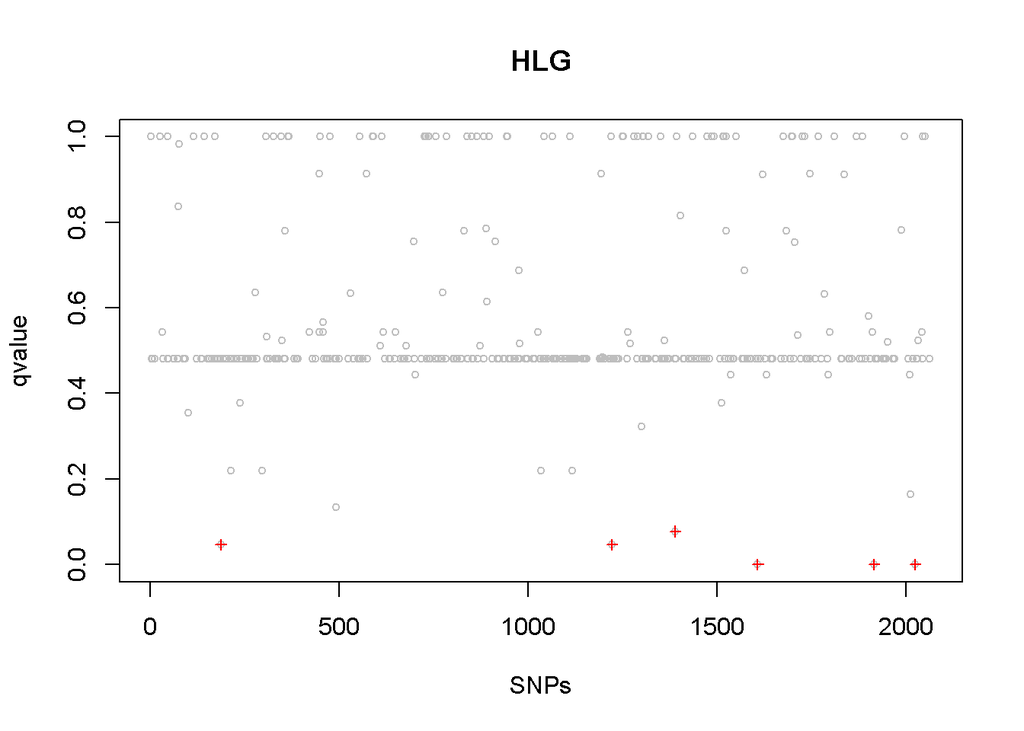

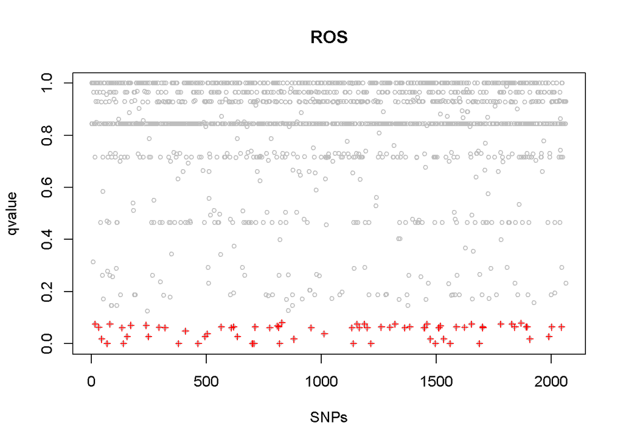

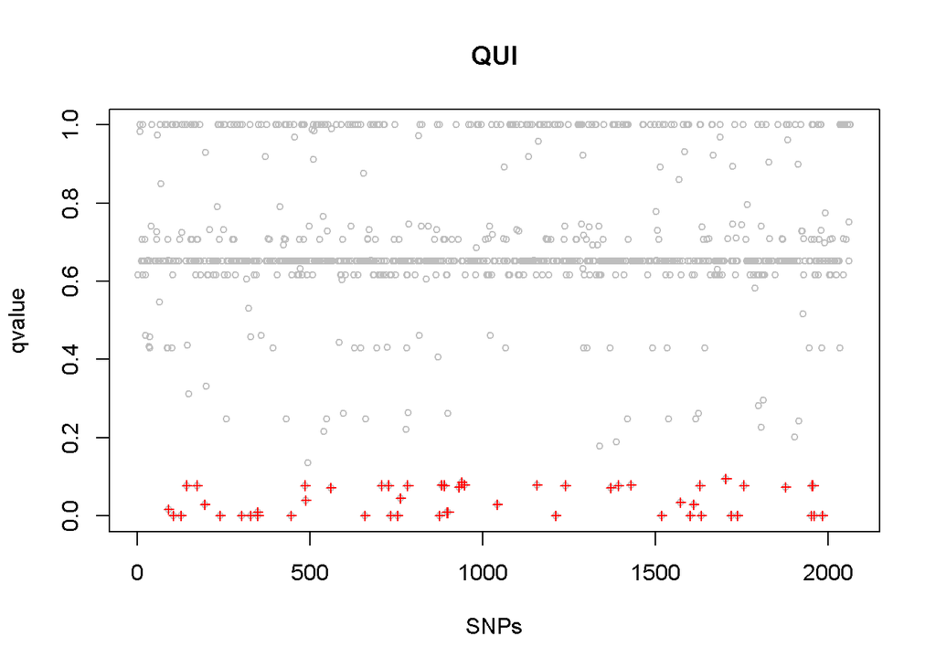

### 3. Reporting and filtering outlier SNPs previously identified using a qvalue threshold

```r
CHROM_POS<-data.frame(seq(1,length(getCHROM(obj.vcfR))), getCHROM(obj.vcfR),getPOS(obj.vcfR),getID(obj.vcfR) ,qval[[1]],qval[[2]],qval[[3]])
colnames(CHROM_POS) <- c("n","CHROM","POS","ID", "qval_HLG", "qval_ROS", "qval_QUI")

outliers_SNP_pop <- list()

for (i in 1: length(POP)){
  outlier_SNP <-filter(CHROM_POS, n %in% outliers_HighFST[[i]])
  outliers_SNP_pop[[i]] <- cbind(outlier_SNP, rep(POP[[i]],length(outliers_HighFST[[i]])))
}

outliers_df_highFST <- rbind(outliers_SNP_pop[[1]],outliers_SNP_pop[[2]],outliers_SNP_pop[[3]])
colnames(outliers_df_highFST) <- c("n","CHROM","POS","ID", "qval_HLG", "qval_ROS", "qval_QUI","pop_detected")

  #report the total number of outlier over populations
  outliers_df_highFST_unique <-outliers_df_highFST[!duplicated(outliers_df_highFST$n), ]
  print(paste("Total number of outlier over populations",length(unique(outliers_df_highFST$ID))))
```

```
## [1] "Total number of outlier over populations 131"
```

```r
  #report the number of SNPs detected twice in different populatons
  occ_SNPs <- table(unlist(outliers_df_highFST$ID))
  occurences <- melt(occ_SNPs)

  multiple_occ <- occurences %>%
    filter(value >= 2)

  multiple_occ_pop <-filter(outliers_df_highFST, ID %in% multiple_occ[,1])
  multiple_occ_pop <-multiple_occ_pop[
    order(multiple_occ_pop[,1]),]
```

### 4. Reporting the upper limit of neutral expectation

99% centile of simulated F<sub>ST</sub> values for each SNP

```r
pop_TempFST <- list()
for (i in 1:length(POP)){

quantile0.01 <-rowQuantiles(as.matrix(FST[[i]][1:n+3]), probs=0.01, na.rm = TRUE)
quantile99 <-rowQuantiles(as.matrix(FST[[i]][1:n+3]), probs=0.99, na.rm = TRUE)

df_pop <-data.frame(CHROM_POS,FST[[i]][,3],quantile0.01,quantile99)
names(df_pop)[8] <- "TempFST"

    df_TempDiff_pop<-df_TempDiff%>%filter(pop == POP[[i]])

    df_OutFLANK_pop <- df_OutFLANK%>%filter(pop == POP[[i]])

    df_pop <- df_pop%>%
              mutate(SLiM_simulations= ID %in% outliers_SNP_pop[[i]]$ID,
                     TempoDiff= ID %in% df_TempDiff_pop$ID,
                     OutFLANK = ID %in% df_OutFLANK_pop$ID)

      df_pop[df_pop == "FALSE"] <- 0
      df_pop[df_pop == "TRUE"] <- 1
      df_pop <- df_pop[,c(1:4,8:13)]

    df_subset <- df_pop%>%
      mutate(twotest= rowSums(.[8:10],na.rm = T))

    df_neutre <- df_subset%>% filter(twotest ==0)%>%
      filter(quantile0.01 != "NA")

    df_two_tests <- df_subset%>%filter(twotest ==2)
    df_three_tests <- df_subset%>%filter(twotest ==3)

    df_SLiM_simulations_uniq <- df_subset%>%
      filter(SLiM_simulations ==1 & TempoDiff ==0)

pop_TempFST[[i]] <-ggplot(df_neutre, aes(x = n, y = quantile99))+
  geom_line(color = "darkgreen",size = 0.01, alpha = 0.4)+
  geom_line(aes(x = n, y = quantile0.01), color = "darkgreen",size = 0.01, alpha = 0.4)+
  geom_point(data = df_neutre,aes(x = n, y = TempFST),colour="grey84",size = 1,shape = 4)+
    geom_point(data = df_SLiM_simulations_uniq,aes(x = n, y = TempFST),fill = "grey",size = 2,shape = 25)+
    geom_point(data = df_two_tests,aes(x = n, y = TempFST),fill = "purple",size = 2.5,shape = 25)+
    geom_point(data = df_three_tests,aes(x = n, y = TempFST),fill = "red",size = 2.5,shape = 25)+
  scale_y_continuous(limits = c(-0.05,0.25),breaks = c(0,0.05,0.10,0.15,0.20,0.25),name = expression(F[ST]))+
  scale_x_continuous(breaks = c(1,500,1000,1500,2067),name = 'SNPs')+
  theme(axis.text.x=element_text(colour="black", size = 12,angle = 45,hjust=0.95,vjust=0.9),
        axis.title = element_text(colour="black", size=12),
        axis.text.y=element_text(colour="black", size = 12),
        panel.background = element_rect(fill="white"),
        panel.grid.minor = element_blank(),
        panel.border = element_rect(colour="black", fill=NA, size=0.5),
        strip.text = element_text(colour="black", size=10),
        legend.position = "bottom",
        legend.text = element_text())
}

#HLG
pop_TempFST[[1]] <- pop_TempFST[[1]] + scale_x_continuous(name = '',expand = c(0.01,0.01)) + theme(axis.text.x=element_blank())
#ROS
pop_TempFST[[2]] <- pop_TempFST[[2]] +  scale_x_continuous(name = '',expand = c(0.01,0.01))+ theme(axis.text.x=element_blank())
#QUI
pop_TempFST[[3]] <- pop_TempFST[[3]] + scale_x_continuous(name = 'SNPs',expand = c(0.01,0.01))
```

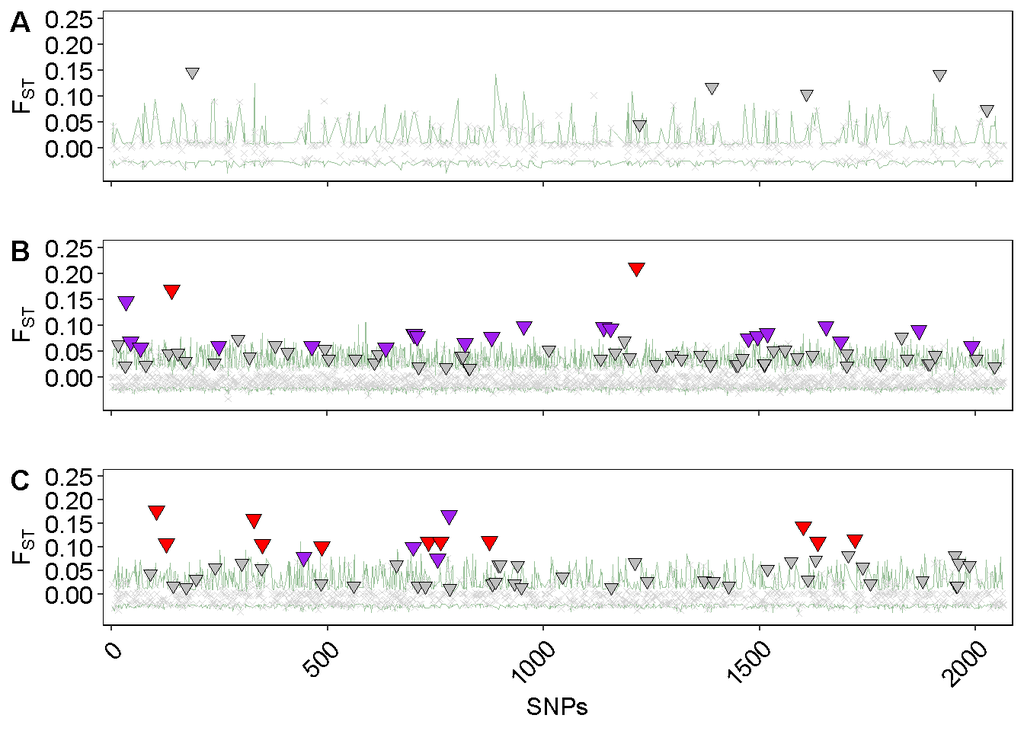

```r
plot(ggarrange(pop_TempFST[[1]], ggparagraph(text=" ", face = "italic", size = 10, color = "black"),
          pop_TempFST[[2]], ggparagraph(text=" ", face = "italic", size = 10, color = "black"),
          pop_TempFST[[3]], ncol = 1, nrow = 5, labels=c("A", "", "B", "", "C"), heights=c(1.5,0.01,1.5,0.01,1.80), widths=c(1, 1, 1, 1, 1), common.legend = TRUE, legend="bottom" ))
```

**Figure 3. Temporal F<sub>ST</sub> per SNP are compared to the upper limit of the neutral expectation based on the high Ne scenario. The green line represents the 99% quantile of F<sub>ST</sub> values expected under genetic drift alone, determined from 5 000 simulations for (A) HLG, (B) ROS, and (C) QUI. Outlier SNPs that are significant after correction for multiple comparisons and detected only by the simulation framework are represented by grey triangles. Those detected by two or three methods are represented by purple and red triangles, respectively. Grey crosses indicate putatively neutral SNPs that were not detected by outlier tests**